# Coursework Report

*N* removed NAs: 3

*N* removed typo: 1

*N* removed <18: 21

*N* total clean: 125

| Group | *N* | *M*<sub>age</sub> | *M*<sub>rating</sub> |
| --- | --- | --- | --- |
| Control | 59 | 20.98 | 6.56 |
| Experim | 66 | 20.97 | 5.69 |

**Main analysis results**

*t*(123) = 6.17, *p* < .001

[interactive chart not shown]

[figure not shown]

[interactive chart not shown]

# Coursework Report

Analysing Data, Spring 2020

# Methods

## Participants

Initially this study consisted of 150 participants but 25 participants had to be removed from the data. This was due 21 participants having ages under 18 years old, three participants didn’t provide age and one incorrectly typed their age with a letter character. These factors made the data inappropriate to use and therefore was removed. After the removal of inappropriate participant data the sample consisted of 125 women aged from 18 to 27, shown in Table 1.

Table 1. Descriptive statistics for age organised by condition

| group | n | mean | sd |
| --- | --- | --- | --- |
| control | 59 | 20.98 | 1.93 |
| experimental | 66 | 20.97 | 2.30 |

## Design

This study was conducted with an independent measures design with the aim of finding out of if women found men more attractive when they were pictured with the colour red. Women in the experimental condition were shown a photo of a man on a red background, and women in the control condition were shown a photo of the same man but on a white background. When they were shown the image, the participants were asked to rate the man in the images’ attractiveness on three scales. With the scale ranging from one to nine, one representing low attractiveness and nine representing high attractiveness. It is hypothesized that women in the experimental condition who are shown the image of the man on a red background will rate him as significantly more attractive than the women in the control group who will view an image of the same man on a white background. In order to test the significance of these results I used a t-test to see if there is a significant difference between the perceived attraction of men pictured wearing white compared to men pictured wearing red.

# Results

We investigated the potential effect that viewing men pictured on a red background compared to men pictured on a white background can have on perceived attractiveness.The mean score for each item in both conditions is shown in Table 2.

Table 2. Mean score for each item from both conditions

| group | item_1 | item_2 | item_3 |
| --- | --- | --- | --- |
| control | 6.54 | 6.56 | 6.58 |
| experimental | 5.73 | 5.67 | 5.67 |

In order to analyse the data gathered from this experiment, a composite score was made by taking the mean of each participants score on the three attractiveness scales. The analysis from the composite score and results from the t-test indicates that participants in the control condition that saw the image of the man on a white background gave higher attractiveness ratings (*M* = 6.56) than participants in the experimental condition who viewed the image of the man on a red background (*M* = 5.69).

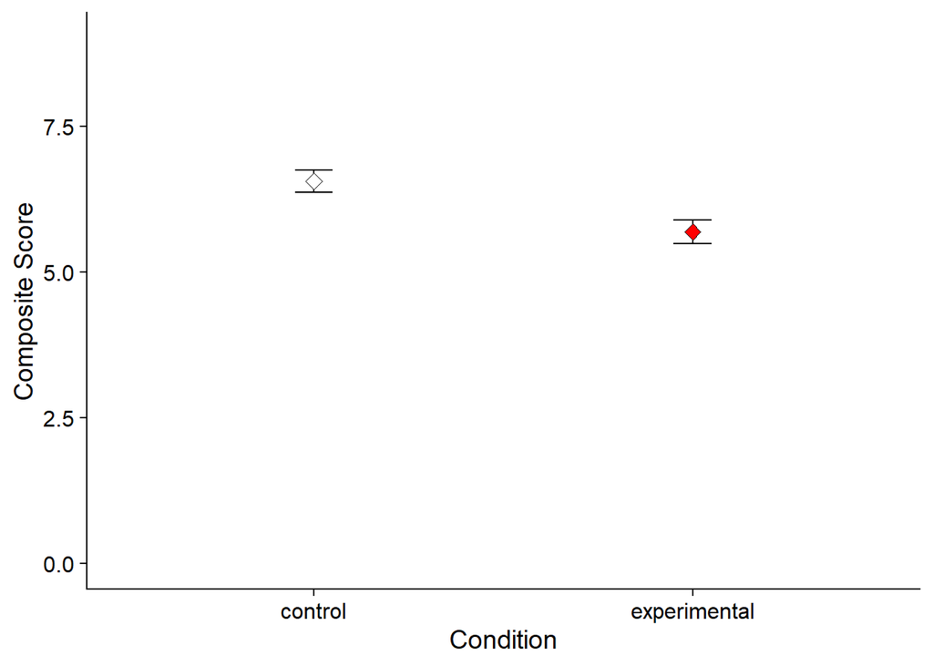

Figure 1. A means plot showing composite score of attractiveness in both conditions

The results from the t-test show that there is a significant difference between the sample groups (*M*<sub>diff</sub> = 0.87, 95% CI [0.59, 1.15]) (*t* (123) = 6.17, *p* < 0.01) .Therefore we can assume that these results are not due to chance and are a result of the differences between the conditions. However due to the pattern of these results the null hypothesis will have to be accepted. As although there is a significant difference, the effect shown is the opposite to the one that was expected from this experiment.

# Discussion

The results obtained from this study show a significant difference between the two conditions. However it is the opposite difference to what was originally hypothesized The results show that the women in the control group who were shown the image of the man on a white background rated him higher on the three measures of attractiveness than the women in the experimental group who were shown an image of the same man on a red background. These results directly contradict the study done by Elliot, Kayser, Greitemeyer, Lichtenfeld, Gramzow, Maier and Liu (2010), as the results from that study show the opposite effect. With women viewing the image of a man on a red background rating him higher on the three measures compared to the control group. This suggests that perhaps this red effect found in the previous study is not as effective as suggested in the original study. This idea is supported by the study by Peperkoorn, Roberts and Pollet (2016) as their results did not show a significant difference between the control and experimental groups and therefore do not support Elliot’s red effect.

This shows a potential weakness in this study as it was not successful in replicating the red effect shown in the study by Elliot et al (2010) and provides support for an opposite effect. Additionally the results from the study may not be generalisable to every women in the population as the sample was only made up of 125 women so cannot be generalized to every woman. However a strength of this study is that it did produce results which show a significant difference between the two conditions.

Further study could be carried out on this area of research, however it may not produce helpful results as some studies done with the aim to provide evidence supporting the experiments carried out by Elliot et al(2010) created results that actually disprove the original findings. Such as the paper by Hesslinger, Goldbach and Carbon (2015); in which they found that when they recreated the study carried out by Elliot et al (2010), they could not find a significant effect in viewing men in conjunction with the colour red making them more attractive. However their findings did suggest that women viewing men in formal clothing found them more attractive so perhaps that would be a better avenue of study than continued study into this red effect. Due to this study and studies conducted in the past i do not believe that the red effect hypothesized by Elliot et al (2010) is real. As there is more evidence disproving this effect than there is proving it.

In conclusion the results from this study suggest that women may find men viewed in conjunction with the colour white more attractive than men viewed in conjunction with the colour red. These results further a trend of research disproving the idea of the red effect which was introduced through the Elliot et al (2010) paper. And due to the experiments done on this topic, I don’t believe the red effect exists. Or at least if it does it has a negligible effect on how attractive women perceive men to be.

# References

Elliot, A. J., Niesta Kayser, D., Greitemeyer, T., Lichtenfeld, S., Gramzow, R. H., Maier, M. A., & Liu, H. (2010). Red, rank, and romance in women viewing men. *Journal of Experimental Psychology: General, 139*(3), 399.

Hesslinger, V. M., Goldbach, L., & Carbon, C. C. (2015). Men in red: A reexamination of the red-attractiveness effect. *Psychonomic bulletin & review, 22*(4), 1142-1148.

Peperkoorn, L. S., Roberts, S. C., & Pollet, T. V. (2016). Revisiting the red effect on attractiveness and sexual receptivity: No effect of the color red on human mate preferences. *Evolutionary Psychology, 14*(4).